# Data Programming

Homework 5, 2024

**EN**

**General guidelines for all homework assignments (click to expand):**

- If found cheating you will be subject to the punishment as desribed in the rulebook “Rules on examination and assessment of knowledge”, which is available at https://www.famnit.upr.si/sl/o-fakulteti/pravilniki-obrazci
- Use vector operations instead of loops if possible.
- Unless specified otherwise, only packages learned in the lectures/tutorials may be used (default: base, datasets, graphics, drDevices, methods, stats, utils; custom: tidyverse, lubridate, readxl, writexl, …).

Some key differences between Quarto and R scripts:

- Importing, exporting is relative to the location of the qmd file and not the project directory.
- Do not try to display enourmous data frames as rendering will take a long time.
- Load the custom packages you are using (or use prefixes such as base::_).
- Careful when redering: error: true allows compilation regardless of critical errors.

Submit a **.html** file created using Quarto via e-classroom. Display all code (packages, input) and output.

Import the database from https://www.kaggle.com/datasets/konradb/fatal-encounters-database

It contains the 2 dataframes shown below.

|  | Abbreviation | Name | X | Population..2015.est.. | Population..2010. | Population..2005. | Population..2000. |
| --- | --- | --- | --- | --- | --- | --- | --- |
| 1 | AL | Alabama | State | 4 858 979 | 4822023 | 4557808 | 4 452 339 |
| 2 | AK | Alaska | State | 738 432 | 731449 | 663661 | 627 500 |
| 3 | AZ | Arizona | State | 6 828 065 | 6553255 | 5939292 | 5 165 993 |
| 4 | AR | Arkansas | State | 2 978 204 | 2949131 | 2779154 | 2 678 511 |
| 5 | CA | California | State | 39 144 818 | 38041430 | 36132147 | 34 002 756 |
| 6 | CO | Colorado | State | 5 456 574 | 5187582 | 4665177 | 4 326 926 |

|  | Unique.ID | Name | Age | Gender | Race | Race.with.imputations | Imputation.probability | URL.of.image..PLS.NO.HOTLINKS. | Date.of.injury.resulting.in.death..month.day.year. | Location.of.injury..address. | Location.of.death..city. | State | Location.of.death..zip.code. | Location.of.death..county. | Full.Address | Latitude | Longitude | Agency.or.agencies.involved | Highest.level.of.force | UID.Temporary | Name.Temporary | Armed.Unarmed | Alleged.weapon | Aggressive.physical.movement | Fleeing.Not.fleeing | Description.Temp | URL.Temp | Dispositions.Exclusions.INTERNAL.USE..NOT.FOR.ANALYSIS | Intended.use.of.force..Developing. | … |
| --- | --- | --- | --- | --- | --- | --- | --- | --- | --- | --- | --- | --- | --- | --- | --- | --- | --- | --- | --- | --- | --- | --- | --- | --- | --- | --- | --- | --- | --- | --- |
| 1 | 25747 | Mark A. Horton | 21 | Male | African-American/Black | African-American/Black | Not imputed |  | 01/01/2000 | Davison Freeway | Detroit | MI | 48203 | Wayne | Davison Freeway Detroit MI 48203 Wayne | 42,4045258 | -83,0922741 |  | Vehicle |  |  |  |  |  |  |  |  | Unreported | Pursuit | … |
| 2 | 25748 | Phillip A. Blurbridge | 19 | Male | African-American/Black | African-American/Black | Not imputed |  | 01/01/2000 | Davison Freeway | Detroit | MI | 48203 | Wayne | Davison Freeway Detroit MI 48203 Wayne | 42,4045258 | -83,0922741 |  | Vehicle |  |  |  |  |  |  |  |  | Unreported | Pursuit | … |
| 3 | 25746 | Samuel H. Knapp | 17 | Male | European-American/White | European-American/White | Not imputed |  | 01/01/2000 | 27898-27804 US-101 | Willits | CA | 95490 | Mendocino | 27898-27804 US-101 Willits CA 95490 Mendocino | 39,4708829 | -123,3617513 | Mendocino County Sheriff's Office | Vehicle |  |  |  |  |  |  |  |  | Unreported | Pursuit | … |
| 4 | 25749 | Mark Ortiz | 23 | Male | Hispanic/Latino | Hispanic/Latino | Not imputed |  | 01/01/2000 | 600 W Cherry Ln | Carlsbad | NM | 88220 | Eddy | 600 W Cherry Ln Carlsbad NM 88220 Eddy | 32,4500798 | -104,2376427 | Eddy County Sheriff's Office | Vehicle |  |  |  |  |  |  |  |  | Unreported | Pursuit | … |
| 5 | 1 | LaTanya Janelle McCoy | 24 | Female | African-American/Black | African-American/Black | Not imputed |  | 01/02/2000 | 5700 block Mack Road | Sacramento | CA | 95823 | Sacramento | 5700 block Mack Road Sacramento CA 95823 Sacramento | 38.4739487 | -121.4337757 | Sacramento Police Department | Vehicle |  |  |  |  |  |  |  |  | Unknown | Pursuit | … |

Answer the questions:

1. Show the number of fatalities per state (full name of state required). Futhermore, plot the results wth a histogram.
2. Plot death by gender across race with a histogram, entirely with R, not with markdown/quarto!
3. Plot the outline of the USA by scatterploting the locations of deaths.

```
# A tibble: 51 × 2
# Groups:   State [51]
   State                    n
   <chr>                <int>
 1 Alabama                691
 2 Alaska                 126
 3 Arizona                900
 4 Arkansas               384
 5 California            4892
 6 Colorado               673
 7 Connecticut            142
 8 Delaware                63
 9 District of Columbia    88
10 Florida               1851
# ℹ 41 more rows
```

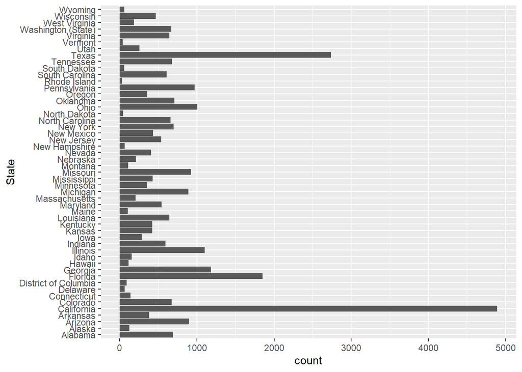

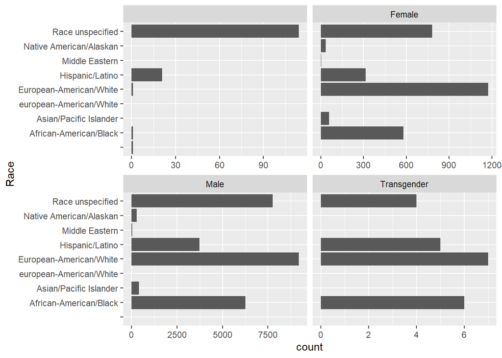

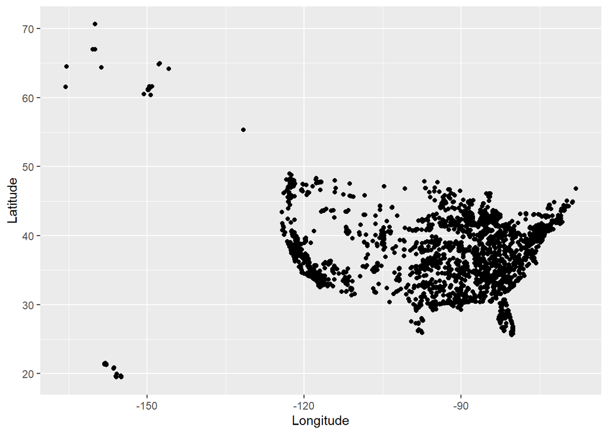

**SLO**

**Splošna navodila za vse domače naloge (klikni za prikaz):**

- V primeru goljufanja boste kaznovani po pravilniku “Pravilnik o preverjanju in ocenjevanju znanja”, ki je dostopen na https://www.famnit.upr.si/sl/o-fakulteti/pravilniki-obrazci
- Če je mogoče, uporabite vektorske operacije namesto zank.
- Če ni določeno drugače, so dovoljeni samo paketi, iz predavanj/vaj (privzeti: base, datasets, graphics, drDevices, methods, stats, utils; po meri: tidyverse, lubridate, readxl, writexl, …).

Nekaj ključnih razlik med R skripto in Quarto:

- Uvoz, izvoz je relativen na lokacijo qmd datoteke in ne z direktorijem projekta.
- Ne poskušajte prikazati ogromnih podatkovnih okvirov, saj bo pletenje trajalo večno.
- Naložite pakete po meri, ki jih uporabljate (ali pa uporabite predpone, kot je base::_).
- Previdno pri pletenju: error: true omogoča prevajanje ne glede na kritične napake.

Predložite datoteko .html, ki je ustvarjena z uporabo Quarta preko e-učilnice. Prikažite vso kodo (pakete, vhod) in izhod.

Uvozite podatkovne bazo iz https://www.kaggle.com/datasets/konradb/fatal-encounters-database

Baza vsebuje 2 podatkovna okvirja, ki sta prikazana spodaj.

|  | Abbreviation | Name | X | Population..2015.est.. | Population..2010. | Population..2005. | Population..2000. |
| --- | --- | --- | --- | --- | --- | --- | --- |
| 1 | AL | Alabama | State | 4 858 979 | 4822023 | 4557808 | 4 452 339 |
| 2 | AK | Alaska | State | 738 432 | 731449 | 663661 | 627 500 |
| 3 | AZ | Arizona | State | 6 828 065 | 6553255 | 5939292 | 5 165 993 |
| 4 | AR | Arkansas | State | 2 978 204 | 2949131 | 2779154 | 2 678 511 |
| 5 | CA | California | State | 39 144 818 | 38041430 | 36132147 | 34 002 756 |
| 6 | CO | Colorado | State | 5 456 574 | 5187582 | 4665177 | 4 326 926 |

|  | Unique.ID | Name | Age | Gender | Race | Race.with.imputations | Imputation.probability | URL.of.image..PLS.NO.HOTLINKS. | Date.of.injury.resulting.in.death..month.day.year. | Location.of.injury..address. | Location.of.death..city. | State | Location.of.death..zip.code. | Location.of.death..county. | Full.Address | Latitude | Longitude | Agency.or.agencies.involved | Highest.level.of.force | UID.Temporary | Name.Temporary | Armed.Unarmed | Alleged.weapon | Aggressive.physical.movement | Fleeing.Not.fleeing | Description.Temp | URL.Temp | Dispositions.Exclusions.INTERNAL.USE..NOT.FOR.ANALYSIS | Intended.use.of.force..Developing. | … |
| --- | --- | --- | --- | --- | --- | --- | --- | --- | --- | --- | --- | --- | --- | --- | --- | --- | --- | --- | --- | --- | --- | --- | --- | --- | --- | --- | --- | --- | --- | --- |
| 1 | 25747 | Mark A. Horton | 21 | Male | African-American/Black | African-American/Black | Not imputed |  | 01/01/2000 | Davison Freeway | Detroit | MI | 48203 | Wayne | Davison Freeway Detroit MI 48203 Wayne | 42,4045258 | -83,0922741 |  | Vehicle |  |  |  |  |  |  |  |  | Unreported | Pursuit | … |
| 2 | 25748 | Phillip A. Blurbridge | 19 | Male | African-American/Black | African-American/Black | Not imputed |  | 01/01/2000 | Davison Freeway | Detroit | MI | 48203 | Wayne | Davison Freeway Detroit MI 48203 Wayne | 42,4045258 | -83,0922741 |  | Vehicle |  |  |  |  |  |  |  |  | Unreported | Pursuit | … |
| 3 | 25746 | Samuel H. Knapp | 17 | Male | European-American/White | European-American/White | Not imputed |  | 01/01/2000 | 27898-27804 US-101 | Willits | CA | 95490 | Mendocino | 27898-27804 US-101 Willits CA 95490 Mendocino | 39,4708829 | -123,3617513 | Mendocino County Sheriff's Office | Vehicle |  |  |  |  |  |  |  |  | Unreported | Pursuit | … |
| 4 | 25749 | Mark Ortiz | 23 | Male | Hispanic/Latino | Hispanic/Latino | Not imputed |  | 01/01/2000 | 600 W Cherry Ln | Carlsbad | NM | 88220 | Eddy | 600 W Cherry Ln Carlsbad NM 88220 Eddy | 32,4500798 | -104,2376427 | Eddy County Sheriff's Office | Vehicle |  |  |  |  |  |  |  |  | Unreported | Pursuit | … |
| 5 | 1 | LaTanya Janelle McCoy | 24 | Female | African-American/Black | African-American/Black | Not imputed |  | 01/02/2000 | 5700 block Mack Road | Sacramento | CA | 95823 | Sacramento | 5700 block Mack Road Sacramento CA 95823 Sacramento | 38.4739487 | -121.4337757 | Sacramento Police Department | Vehicle |  |  |  |  |  |  |  |  | Unknown | Pursuit | … |

Odgovorite na vprašanja:

1. Prikažite število smrtnih žrtev po zveznih državah (obvezna uporaba celotnih imen zveznih držav). Rezultate nato še prikažite s histogramom.
2. S histogramom izrišite smrtne žrtve glede na raso, za vsak spol. Rešite v celoti z Rjem, ne z markdown/quarto!
3. Narišite obris ZDA z razpršlnim grafikonom krajev smrti.

```
# A tibble: 51 × 2
# Groups:   State [51]
   State                    n
   <chr>                <int>
 1 Alabama                691
 2 Alaska                 126
 3 Arizona                900
 4 Arkansas               384
 5 California            4892
 6 Colorado               673
 7 Connecticut            142
 8 Delaware                63
 9 District of Columbia    88
10 Florida               1851
# ℹ 41 more rows
```

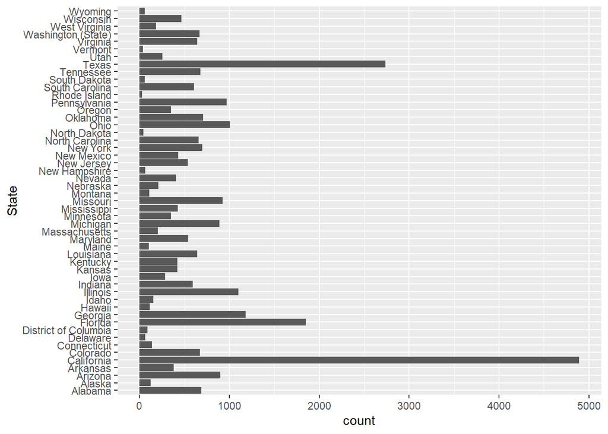

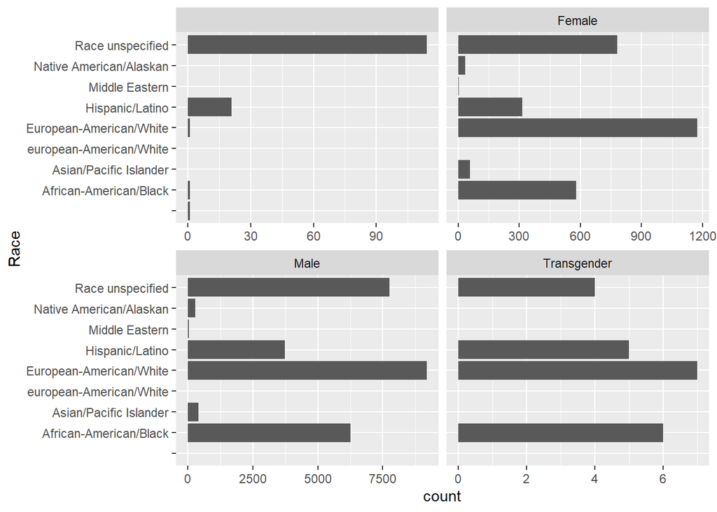

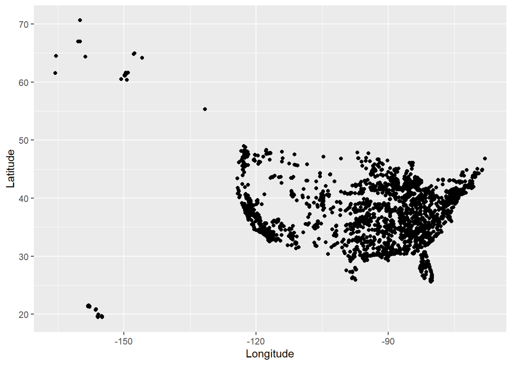